# Partner Perception

Author

Gabriela Cervantes

## About This Report

This reproducible report documents the data preparation, variable construction, descriptive statistics, primary analyses, and figures for this study.

The report is intended to accompany a manuscript-style research paper. It is not the full paper itself. Instead, it shows how the reported analyses were produced from the dataset using a transparent and reproducible Quarto workflow.

## Study Overview

The design included one manipulated independent variable and 2 categorical moderators:

- Vignette condition: negative partner scenario versus positive partner scenario
- Attachment moderator: secure attachment versus insecure attachment
- Culture moderator: collectivistic values vs individualistic values

The dependent variable was partner attribution patterns.

The primary analyses tested whether vignette condition, attachment, and culture had an influence on partner attribution patters.

## Set up & Software Environment

This section loads the packages used for data preparation, scale construction, statistical modeling, estimated marginal means, and figures.

```r
# Set global chunk options for the entire document
knitr::opts_chunk$set(
  echo = TRUE, # display code in output
  message = FALSE, # suppress package messages
  warning = FALSE # suppress warnings
  )
# Prevent automatic conversion of strings to factors
options(stringsAsFactors = FALSE) # keep character variables as tex
```

```r
# Load data manipulation tools
library(tidyverse) # includes dplyr, readr, etc.
# Load scale construction tools
library(psych) # functions for scale analysis
# Load analysis tools
library(afex) # ANOVA models
library(emmeans) # estimated marginal means
```

## Load Data

The dataset was imported from the project `data` folder.

```r
data <- read.csv("data/partner_perception_clean.csv")
```

```r
# Excluding participants with missing data
data <- data %>%
  filter(
    if_all("RAM_1":"Condition",
           ~! is.na(.))
  )
```

```r
# Print all variable names in the dataset
names(data) # lists all column names for inspection
```

```
 [1] "ResponseId"          "DistributionChannel" "consent.question"
 [4] "RAM_1"               "RAM_2"               "RAM_3"
 [7] "RAM_4"               "RAM_5"               "RAM_6"
[10] "cult_1"              "cult_2"              "cult_3"
[13] "cult_4"              "cult_5"              "cult_6"
[16] "cult_7"              "cult_8"              "cult_9"
[19] "cult_10"             "cult_11"             "cult_12"
[22] "cult_13"             "cult_14"             "cult_15"
[25] "cult_16"             "attach"              "Gender"
[28] "Age"                 "Condition"
```

## Variable Preparation and Scale Construction

This section prepares the variables used in the primary analyses. The original imported dataset was left unchanged; all prepared variables were created in the working analysis dataset, `data`.

```r
# Create a vector of variables included in the study
study_vars <- c(
  "Condition",  # experimental condition variable
  "attach",       # participant attachment style
  "Gender",       # participant gender
  "Age",       # participant age
  "RAM_1","RAM_2","RAM_3","RAM_4","RAM_5","RAM_6",  # RAM items
  "cult_1","cult_2","cult_3","cult_4","cult_5","cult_6","cult_7","cult_8","cult_9","cult_10","cult_11","cult_12", "cult_13","cult_14","cult_15","cult_16"  # culture items
)

# Check the number of variables in the list
length(study_vars)  # confirms total number matches expected count
```

```
[1] 26
```

### **Create the analysis dataset**

The analysis dataset contains the variables required for the report.

```r
# Subset the dataset to include only study variables
data <- data[, study_vars] # keeps only selected variables

# Confirm the dataset structure after subsetting
names(data) # verifies correct variables are retain
```

```
 [1] "Condition" "attach"    "Gender"    "Age"       "RAM_1"     "RAM_2"
 [7] "RAM_3"     "RAM_4"     "RAM_5"     "RAM_6"     "cult_1"    "cult_2"
[13] "cult_3"    "cult_4"    "cult_5"    "cult_6"    "cult_7"    "cult_8"
[19] "cult_9"    "cult_10"   "cult_11"   "cult_12"   "cult_13"   "cult_14"
[25] "cult_15"   "cult_16"
```

### **Label the experimental condition**

```r
# Verify condition counts
data %>%
  count(Condition) # counts observations in each condition
```

```
  Condition  n
1  Negative 38
2  Positive 35
```

### **Create participant ID**

```r
# Create a unique ID for each participant
data <- data %>%
  mutate(id = row_number()) # assigns sequential ID values
# Preview the ID variable
data %>% select(id) %>% head() # confirms ID structure
```

```
  id
1  1
2  2
3  3
4  4
5  5
6  6
```

### **Reverse-code scale items**

Items requiring reverse coding were transformed before scale scores were computed. Because the items used a 1–9 response scale, reverse-coded items were created by subtracting each original item response from 10.

```r
# Reverse-code selected depression items
data <- data %>%
  mutate(cult_2_r = 10 - cult_2,
         cult_4_r = 10 - cult_4,
         cult_7_r = 10 - cult_7,
         cult_8_r = 10 - cult_8,
         cult_11_r = 10 - cult_11,
         cult_12_r = 10 - cult_12,
         cult_15_r = 10 - cult_15,
         cult_16_r = 10 - cult_16
         )

# Compare original and reversed values
data %>%
  select(cult_2, cult_2_r) %>% # selects variables for comparison
  head() # displays first rows
```

```
  cult_2 cult_2_r
1      6        4
2      5        5
3      8        2
4      6        4
5      8        2
6      8        2
```

### Culture

**Define Culture Items**

```r
# Define culture scale items
cult_items <- c(
  "cult_1", "cult_2_r", "cult_3", "cult_4_r", "cult_5", "cult_6", "cult_7_r", "cult_8_r", "cult_9", "cult_10", "cult_11_r", "cult_12_r", "cult_13", "cult_14", "cult_15_r", "cult_16_r"
  )
# Check that all items exist in dataset
setNames(cult_items %in% names(data), cult_items) # verifies item presence
```

```
   cult_1  cult_2_r    cult_3  cult_4_r    cult_5    cult_6  cult_7_r  cult_8_r
     TRUE      TRUE      TRUE      TRUE      TRUE      TRUE      TRUE      TRUE
   cult_9   cult_10 cult_11_r cult_12_r   cult_13   cult_14 cult_15_r cult_16_r
     TRUE      TRUE      TRUE      TRUE      TRUE      TRUE      TRUE      TRUE
```

**Compute Culture score**

```r
# Compute culture scale as the row mean of items
data <- data %>%
  mutate(cult_scale = rowMeans(as.matrix(across(all_of(cult_items))), na.rm = TRUE) # calculates scale score
         )

# Check proportion of missing scale scores
mean(is.na(data$cult_scale)) # should be close to 0
```

```
[1] 0
```

### RAM

**Define RAM Items**

```r
# Define RAM scale items
RAM_items <- c(
  "RAM_1", "RAM_2", "RAM_3", "RAM_4", "RAM_5", "RAM_6"
)

setNames(RAM_items %in% names(data), RAM_items) # verifies item presence
```

```
RAM_1 RAM_2 RAM_3 RAM_4 RAM_5 RAM_6
 TRUE  TRUE  TRUE  TRUE  TRUE  TRUE
```

**Compute RAM Score**

```r
data <- data %>%
  mutate(RAM_scale = rowMeans(as.matrix(across(all_of(RAM_items))), na.rm = TRUE) # calculates scale score
         )

mean(is.na(data$RAM_scale)) # should be close to 0
```

```
[1] 0
```

### **Culture Median Split**

A low/high culture grouping variable was created for the planned 2 × 2 ANOVA models. Participants with culture scores at or below the sample median were assigned to the Low group, and participants above the sample median were assigned to the High group.

```r
# Compute median culture score
cult_median <- median(data$cult_scale, na.rm = TRUE)

# Create low/high culture groups
data <- data %>%
  mutate(
    cult_msplit = if_else(cult_scale <= cult_median, "Low", "High"),
    cult_msplit = factor(cult_msplit, levels = c("Low", "High"))
  )

# Print median
cult_median
```

```
[1] 4.5625
```

```r
# Check group sizes
data %>%
  count(cult_msplit) %>%
  knitr::kable()
```

| cult_msplit | n |
| --- | --- |
| Low | 40 |
| High | 33 |

### **Check Scale Scores**

The scale-score checks confirm that the computed scale scores fall within the expected response range and show whether any scale scores are missing.

```r
data %>%
  select(
    RAM_scale,
    cult_scale
  ) %>%
  summary()
```

```
   RAM_scale       cult_scale
 Min.   :1.833   Min.   :3.062
 1st Qu.:3.167   1st Qu.:4.250
 Median :3.500   Median :4.562
 Mean   :3.548   Mean   :4.558
 3rd Qu.:4.167   3rd Qu.:4.875
 Max.   :5.000   Max.   :6.000
```

```r
data %>%
  summarise(
    RAM_scale_missing = mean(is.na(RAM_scale)),
    cult_scale_missing = mean(is.na(cult_scale))
  ) %>%
  knitr::kable()
```

| RAM_scale_missing | cult_scale_missing |
| --- | --- |
| 0 | 0 |

### **Create Attachment Groups**

```r
# Create attachment groups from the single attachment-style item
data <- data %>%
  mutate(
    attach_group = case_when(
      attach == 1 ~ "Secure",
      attach %in% c(2, 3) ~ "Insecure",
      TRUE ~ NA_character_
    ),
    attach_group = factor(
      attach_group,
      levels = c("Insecure", "Secure")
    )
  )

# Check final attachment group sizes
data %>%
  count(attach_group) %>%
  knitr::kable()
```

| attach_group | n |
| --- | --- |
| Insecure | 44 |
| Secure | 29 |

### **Check Scale Reliability**

```r
# Create item-only data frames for each multi-item rating scale
RAM_item_df <- data %>%
  select(all_of(RAM_items))

cult_item_df <- data %>%
  select(all_of(cult_items))

# Compute internal consistency estimates
RAM_alpha <- psych::alpha(RAM_item_df)
```

```
Some items ( RAM_5 RAM_6 ) were negatively correlated with the first principal component and
probably should be reversed.
To do this, run the function again with the 'check.keys=TRUE' option
```

```r
RAM_omega <- psych::omega(RAM_item_df, plot = FALSE)

cult_alpha <- psych::alpha(cult_item_df)
```

```
Some items ( cult_1 cult_3 cult_6 cult_9 cult_10 cult_13 cult_14 ) were negatively correlated with the first principal component and
probably should be reversed.
To do this, run the function again with the 'check.keys=TRUE' option
```

```r
cult_omega <- psych::omega(cult_item_df, plot = FALSE)

# Print only alpha and omega coefficients
tibble(
  scale = c(
    "Relationship Attribution Measure",
    "Individualism and Collectivism Scale"
  ),
  alpha = c(
    RAM_alpha$total$raw_alpha,
    cult_alpha$total$raw_alpha
  ),
  omega = c(
    RAM_omega$omega.tot,
    cult_omega$omega.tot
  )
) %>%
  knitr::kable(digits = 2)
```

| scale | alpha | omega |
| --- | --- | --- |
| Relationship Attribution Measure | 0.42 | 0.82 |
| Individualism and Collectivism Scale | 0.40 | 0.84 |

## Descriptive Statistics

This section summarizes the scale scores and sample composition before the primary hypothesis tests.

**Scale Score Descriptives**

```r
data %>%
  select(
    RAM_scale,
    cult_scale
  ) %>%
  psych::describe() %>%
  knitr::kable(digits = 2)
```

|  | vars | n | mean | sd | median | trimmed | mad | min | max | range | skew | kurtosis | se |
| --- | --- | --- | --- | --- | --- | --- | --- | --- | --- | --- | --- | --- | --- |
| RAM_scale | 1 | 73 | 3.55 | 0.71 | 3.50 | 3.60 | 0.74 | 1.83 | 5 | 3.17 | -0.51 | -0.10 | 0.08 |
| cult_scale | 2 | 73 | 4.56 | 0.61 | 4.56 | 4.56 | 0.46 | 3.06 | 6 | 2.94 | 0.00 | 0.02 | 0.07 |

### **Sample Composition by Age & Gender**

```r
# Summarize age
data %>%
  summarise(
    mean_age = mean(Age, na.rm = TRUE),
    sd_age = sd(Age, na.rm = TRUE),
    min_age = min(Age, na.rm = TRUE),
    max_age = max(Age, na.rm = TRUE)
  ) %>%
  knitr::kable(
    digits = 2,
    col.names = c("Mean", "SD", "Minimum", "Maximum"),
    caption = "Sample Age: Mean, Standard Deviation, and Range"
  )
```

Sample Age: Mean, Standard Deviation, and Range

| Mean | SD | Minimum | Maximum |
| --- | --- | --- | --- |
| 21.42 | 1.33 | 18 | 26 |

```r
# Summarize gender
data %>%
  mutate(
    gender_group = factor(
      Gender,
      levels = c(1, 2, 3),
      labels = c("Male", "Female", "Non-binary / Other")
    )
  ) %>%
  count(gender_group) %>%
  mutate(percent = round(100 * n / sum(n), 1)) %>%
  knitr::kable(
    col.names = c("Gender", "n", "Percent"),
    caption = "Sample Composition by Gender"
  )
```

Sample Composition by Gender

| Gender | n | Percent |
| --- | --- | --- |
| Male | 10 | 13.7 |
| Female | 61 | 83.6 |
| Non-binary / Other | 2 | 2.7 |

### Correlations Among the DVs

```r
# Correlations for the main continuous study variables
psych::corr.test(
  data %>%
    select(
      RAM_scale,
      cult_scale
    )
)
```

```
Call:psych::corr.test(x = data %>% select(RAM_scale, cult_scale))
Correlation matrix
           RAM_scale cult_scale
RAM_scale       1.00       0.13
cult_scale      0.13       1.00
Sample Size
[1] 73
Probability values (Entries above the diagonal are adjusted for multiple tests.)
           RAM_scale cult_scale
RAM_scale       0.00       0.28
cult_scale      0.28       0.00

 To see confidence intervals of the correlations, print with the short=FALSE option
```

## Primary Analyses

This section reports the primary analyses used to test whether vignette condition, culrure, attachment, and their interactions predicted partner attribution scores.

Two 2 × 2 ANOVA models were estimated. Both models used vignette conditions as the independent variable and relationship attribution scores as the dependent variable and. In the first model, the categorical moderator was attachment. In the second model, the moderator was culture.

### RAM Model with Attachment

A 2 × 2 ANOVA tested whether attribution scores differed by attachment styles and vignette condition, and the vignette condition × attachment style interaction.

```r
a1_RAM <- afex::aov_ez(
  id = "id",
  dv = "RAM_scale",
  between = c("Condition", "attach_group"),
  data = data
)

# Print the ANOVA table
a1_RAM
```

```
Anova Table (Type 3 tests)

Response: RAM_scale
                  Effect    df  MSE    F   ges p.value
1              Condition 1, 69 0.51 2.49  .035    .119
2           attach_group 1, 69 0.51 0.04 <.001    .847
3 Condition:attach_group 1, 69 0.51 0.15  .002    .700
---
Signif. codes:  0 '***' 0.001 '**' 0.01 '*' 0.05 '+' 0.1 ' ' 1
```

The ANOVA table reports the main effect of vignette condition, the main effect of attachment styles, and the vignette condition × attachment group interaction for partner attributions.

#### Estimated Means for RAM with Attachment

```r
emmeans(a1_RAM, ~ Condition)
```

```
 Condition emmean    SE df lower.CL upper.CL
 Negative    3.42 0.118 69     3.19     3.66
 Positive    3.69 0.125 69     3.44     3.94

Results are averaged over the levels of: attach_group
Confidence level used: 0.95
```

```r
emmeans(a1_RAM, ~ attach_group)
```

```
 attach_group emmean    SE df lower.CL upper.CL
 Insecure       3.54 0.108 69     3.33     3.76
 Secure         3.57 0.134 69     3.31     3.84

Results are averaged over the levels of: Condition
Confidence level used: 0.95
```

```r
emmeans(a1_RAM, ~ Condition * attach_group)
```

```
 Condition attach_group emmean    SE df lower.CL upper.CL
 Negative  Insecure       3.44 0.153 69     3.13     3.74
 Positive  Insecure       3.64 0.153 69     3.34     3.95
 Negative  Secure         3.41 0.179 69     3.05     3.76
 Positive  Secure         3.74 0.199 69     3.35     4.14

Confidence level used: 0.95
```

The estimated means show the relationship attribution pattern across vignette condition, attachment group, and their combined cells.

### RAM Model with Culture

A 2 × 2 ANOVA tested whether attribution scores differed by cultural orientation and vignette condition, and the vignette condition × culture interaction.

```r
# 2x2 between-subjects ANOVA predicting RAM scores
# DV: RAM_scale
# Factors: condition and culture group
a2_RAM_cult <- afex::aov_ez(
  id = "id",
  dv = "RAM_scale",
  between = c("Condition", "cult_msplit"),
  data = data
)

# Print the ANOVA table
a2_RAM_cult
```

```
Anova Table (Type 3 tests)

Response: RAM_scale
                 Effect    df  MSE      F  ges p.value
1             Condition 1, 69 0.48   1.86 .026    .177
2           cult_msplit 1, 69 0.48   0.31 .004    .581
3 Condition:cult_msplit 1, 69 0.48 4.02 * .055    .049
---
Signif. codes:  0 '***' 0.001 '**' 0.01 '*' 0.05 '+' 0.1 ' ' 1
```

The ANOVA table reports the main effect of vignette condition, the main effect of cultural orientation, and the vignette condition × culture interaction for partner attributions.

#### Estimated Means for RAM with Culture

```r
emmeans(a2_RAM_cult, ~ Condition)
```

```
 Condition emmean    SE df lower.CL upper.CL
 Negative    3.45 0.113 69     3.22     3.67
 Positive    3.67 0.118 69     3.44     3.91

Results are averaged over the levels of: cult_msplit
Confidence level used: 0.95
```

```r
emmeans(a2_RAM_cult, ~ cult_msplit)
```

```
 cult_msplit emmean    SE df lower.CL upper.CL
 Low           3.51 0.110 69     3.29     3.73
 High          3.60 0.121 69     3.36     3.85

Results are averaged over the levels of: Condition
Confidence level used: 0.95
```

```r
emmeans(a2_RAM_cult, ~ Condition * cult_msplit)
```

```
 Condition cult_msplit emmean    SE df lower.CL upper.CL
 Negative  Low           3.24 0.152 69     2.94     3.54
 Positive  Low           3.79 0.159 69     3.47     4.11
 Negative  High          3.66 0.169 69     3.32     3.99
 Positive  High          3.55 0.174 69     3.21     3.90

Confidence level used: 0.95
```

The estimated means show the relationship attribution pattern across vignette condition, culture group, and their combined cells.

## Figures

This section creates the figures used to visualize the primary 2 × 2 ANOVA results. The figures are based on the estimated cell means from the ANOVA models.

### RAM with Attachment Interaction Plot

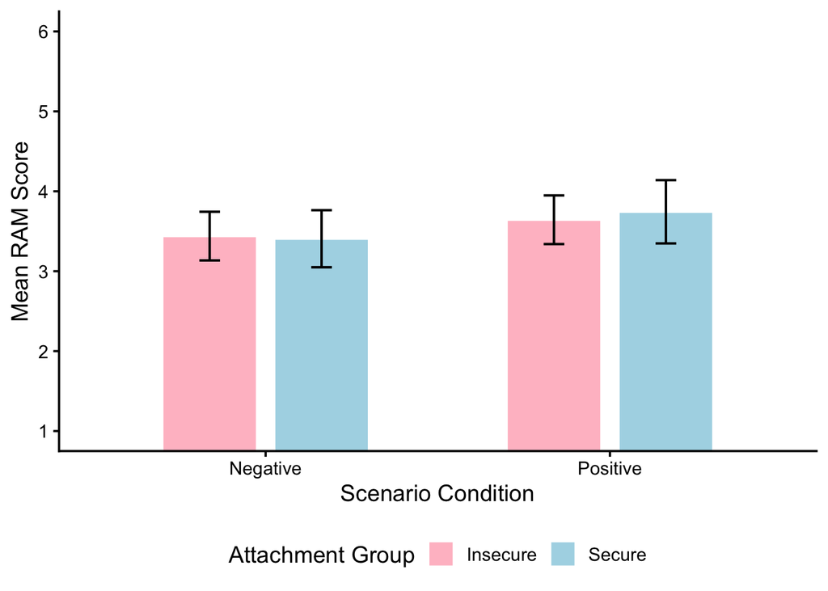

```r
p_RAM_attachment_bar <- ggplot(
  as.data.frame(emmeans(a1_RAM, ~ Condition * attach_group)),
  aes(
    x = Condition,
    y = emmean,
    fill = attach_group
  )
) +
  geom_col(
    position = position_dodge(width = 0.65),
    width = 0.55,
    color = "white"
  ) +
  geom_errorbar(
    aes(
      ymin = lower.CL,
      ymax = upper.CL
    ),
    position = position_dodge(width = 0.65),
    width = 0.12,
    linewidth = 0.7
  ) +
  labs(
    x = "Scenario Condition",
    y = "Mean RAM Score",
    fill = "Attachment Group"
  ) +
  scale_fill_manual(
    values = c(
      "Insecure" = "pink", # YOU CAN CHANGE THESE TWO HEX VALUES TO MATCH YOUR POSTER!
      "Secure" = "lightblue"
    )
  ) +
  scale_y_continuous(
    breaks = seq(1, 6, 1)
  ) +
  coord_cartesian(
    ylim = c(1, 6)
  ) +
  theme_classic(
    base_size = 14
  ) +
  theme(
    legend.position = "bottom"
  )



p_RAM_attachment_bar
```

The figure shows estimated relationship attribution scores by scenario condition and attachment group. Error bars represent 95% confidence intervals.

### RAM with Culture Interaction Plot

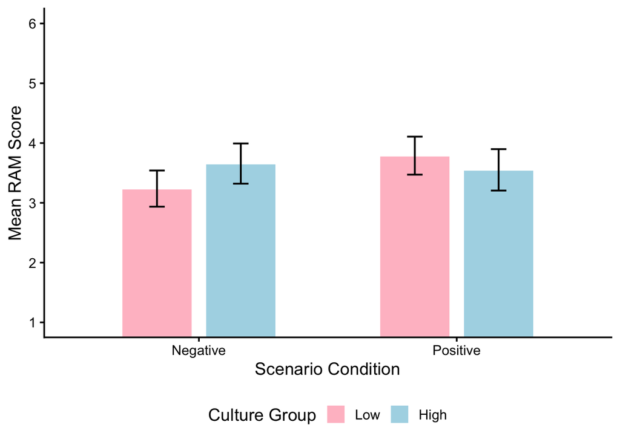

```r
p_culture_bar <- ggplot(
  as.data.frame(emmeans(a2_RAM_cult, ~ Condition * cult_msplit)),
  aes(
    x = Condition,
    y = emmean,
    fill = cult_msplit
  )
) +
  geom_col(
    position = position_dodge(width = 0.65),
    width = 0.55,
    color = "white"
  ) +
  geom_errorbar(
    aes(
      ymin = lower.CL,
      ymax = upper.CL
    ),
    position = position_dodge(width = 0.65),
    width = 0.12,
    linewidth = 0.7
  ) +
  labs(
    x = "Scenario Condition",
    y = "Mean RAM Score",
    fill = "Culture Group"
  ) +
  scale_fill_manual(
    values = c(
      "Low" = "pink", # YOU CAN CHANGE THESE TWO HEX VALUES TO MATCH YOUR POSTER!
      "High" = "lightblue"
    )
  ) +
  scale_y_continuous(
    breaks = seq(1, 6, 1)
  ) +
  coord_cartesian(
    ylim = c(1, 6)
  ) +
  theme_classic(
    base_size = 14
  ) +
  theme(
    legend.position = "bottom"
    )


p_culture_bar
```

The figure shows estimated relationship attribution scores by scenario condition and culture group. Error bars represent 95% confidence intervals.

Export Figures

```r
if (!dir.exists("figures")) {
  dir.create("figures")
}

ggsave(
  filename = "figures/RAM_attachment_interaction_plot.svg",
  plot = p_RAM_attachment_bar,
  width = 7,
  height = 5
)

ggsave(
  filename = "figures/RAM_culture_interaction_plot.svg",
  plot = p_culture_bar,
  width = 7,
  height = 5
)
```

The figures were exported to the `figures/` folder so they can be used in manuscript, poster, or repository materials.

## Results Summary

The primary analyses tested whether scenario condition, attachment styles, cultural orienation, and their interactions predicted relationship attributions. Across both ANOVA models the interaction between culture and scenario conditon was the only statistically significant predictor. Participants in the low culture group (more collectivistic) showed higher RAM scores (more dispositonal attributions) following the positive scenario, whereas participants in the high culture (more individualistic) group responded similarly across conditions, with only slightly higher RAM scores following the negative scenario. The estimated means and interaction plots above provide the full model output and visualize the pattern of results for each outcome.